# Analysis for ‘Perceptual Integrality of Foreign Segmental and Tonal Information: Dimensional Transfer Hypothesis’

William Choi & Rachel Ka-Ying Tsui

2022-10-25

# **Demographics**

## Number of participants

| test_group | language_group | n |
| --- | --- | --- |
| face-to-face | Cantonese | 13 |
| face-to-face | English | 1 |
| online | Cantonese | 25 |
| online | English | 30 |

## Gender of participants

| test_group | language_group | female | male | NA |
| --- | --- | --- | --- | --- |
| face-to-face | Cantonese | 7 | 6 | NA |
| face-to-face | English | 1 | NA | NA |
| online | Cantonese | 17 | 8 | NA |
| online | English | 14 | 15 | 1 |

## Age of participants

| test_group | language_group | mean_age | sd_age | min_age | max_age |
| --- | --- | --- | --- | --- | --- |
| face-to-face | Cantonese | 26.62 | 6.80 | 18 | 42 |
| face-to-face | English | 22.00 | NA | 22 | 22 |
| online | Cantonese | 25.04 | 5.66 | 19 | 39 |
| online | English | 27.77 | 6.30 | 18 | 39 |

# **Stimuli info**

## Number of stimuli

| test_group | control_trial_n | orthogonal_trial_n |
| --- | --- | --- |
| face-to-face | 160 | 160 |
| online | 80 | 80 |

# **Main analysis**

Linear mixed-effects analyses were performed in the R statistical language (Version 4.1.3; R Core Team. 2020) using the lme4 package (Bates, Maechler, Bolker, & Walker, 2015). The lmerTest package (Kuznetsova et al., 2017) was used to calculate the p-values of the models. Our predictor variables were block and language group. Block (control vs. orthogonal) and language group (Cantonese vs. English) were categorical with two levels, with Cantonese control as the reference level. Post-hoc analyses were conducted through pairwise comparisons using the emmeans package (Length, 2022).

## Average plots by block and language group

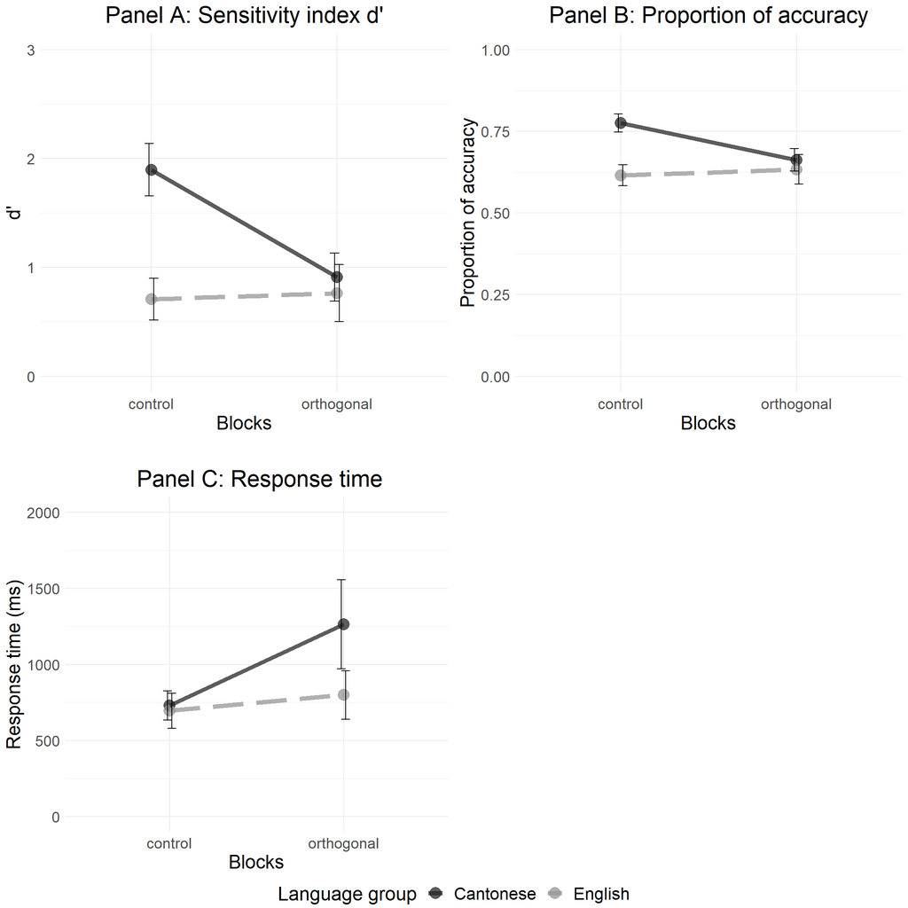

## Accuracy: D’ score

In each block of the modified AX task, the d’ was computed by subtracting the z-transform of the hit rate by that of the false alarm rate (Signal Detection Theory, MacMillan & Creelman, 2005). Each correct AB trial was regarded as a hit whereas each incorrect AA trial was regarded as a false alarm. As in previous studies, we manually adjusted perfect false alarm (0) and hit rates (1.0) to .01 and .99 respectively to avoid infinity d’ (Bidelman, Hutka, & Moreno, 2013; Choi et al., 2019).

### Average d’ score

| test_group | language_group | block | mean_dprime | sd_dprime | min_dprime | max_dprime |
| --- | --- | --- | --- | --- | --- | --- |
| online | Cantonese | control | 1.90 | 0.61 | 0.91 | 3.25 |
| online | Cantonese | orthogonal | 0.91 | 0.56 | 0.13 | 2.28 |
| online | English | control | 0.71 | 0.54 | -0.34 | 1.78 |
| online | English | orthogonal | 0.76 | 0.74 | -0.79 | 2.08 |

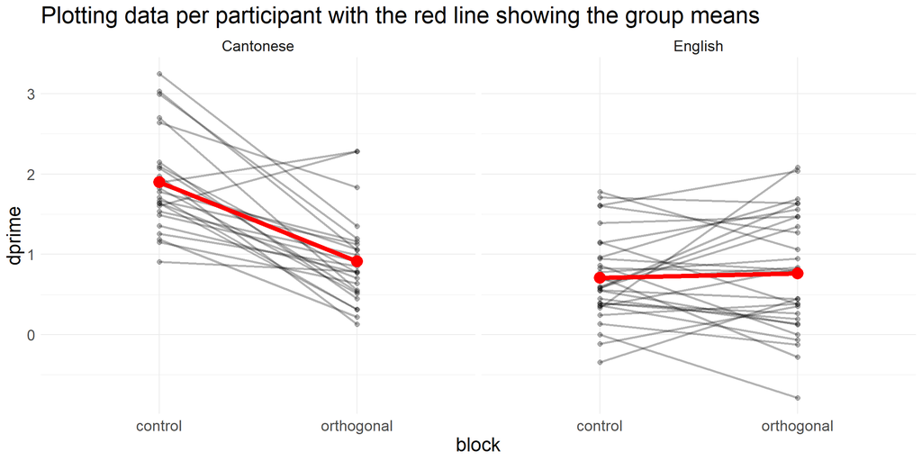

### Linear mixed-effects model

Model ran: lmer(dprime ~ block * language_group + (1|participant_id))

| effect | group | term | estimate | SE | t | df | p.value |
| --- | --- | --- | --- | --- | --- | --- | --- |
| fixed | NA | (Intercept) | 1.896 | 0.124 | 15.297 | 91.39 | <.001 |
| fixed | NA | blockorthogonal | -0.985 | 0.136 | -7.249 | 53.00 | <.001 |
| fixed | NA | language_groupEnglish | -1.189 | 0.168 | -7.084 | 91.39 | <.001 |
| fixed | NA | blockorthogonal:language_groupEnglish | 1.041 | 0.184 | 5.662 | 53.00 | <.001 |
| ran_pars | participant_id | sd__(Intercept) | 0.392 | NA | NA | NA | NA |
| ran_pars | Residual | sd__Observation | 0.480 | NA | NA | NA | NA |

Comparison reference level: Control block × Cantonese group

- Significant effect of **block**: With the negative estimate, the Cantonese group’s performance was lower in the orthogonal block than in the control block.
- Significant effect of **language_group**: With the negative estimate, the Cantonese group showed better performance than the English group in the control block.
- Significant **block × language_group** interaction: The interaction means the effect of block changes with a change in language group. Here the positive estimate suggests that the effect of Cantonese group showing worse performance in the orthogonal block changes when we look at the performance of the English group. The effect of block goes positive for the English group.

### Post-hoc analysis (adjustment method: Bonferroni)

block*language group

```r
emmeans(dprime_model, pairwise ~ block | language_group, adjust = "Bonferroni")[2]
```

```
## $contrasts
## language_group = Cantonese:
##  contrast             estimate    SE df t.ratio p.value
##  control - orthogonal   0.9845 0.136 53   7.249  <.0001
##
## language_group = English:
##  contrast             estimate    SE df t.ratio p.value
##  control - orthogonal  -0.0566 0.124 53  -0.457  0.6496
##
## Degrees-of-freedom method: kenward-roger
```

## Accuracy: Proportion of accuracy

### Average proportion of accuracy

The second accuracy measure was the proportion of trials in each block that listeners gave a correct response to. For each correct trial, a point of 1 was given; otherwise, a point of 0 was given.

| test_group | language_group | block | mean_proportion | sd | min | max |
| --- | --- | --- | --- | --- | --- | --- |
| online | Cantonese | control | 0.78 | 0.07 | 0.59 | 0.91 |
| online | Cantonese | orthogonal | 0.66 | 0.09 | 0.52 | 0.86 |
| online | English | control | 0.62 | 0.09 | 0.44 | 0.81 |
| online | English | orthogonal | 0.63 | 0.13 | 0.35 | 0.85 |

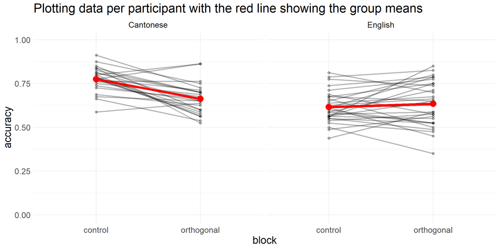

### Logistic mixed-effects model (indiviual item: n = 80)

Model ran: glmer(accuracy ~ block * language_group + (1+ block|participant_id) + (1|item_no) + (1|tone) + (1|syllable)

- participant_id and item_no are deﬁned as two diﬀerent sources of variation in the data. We would expect performance to vary by participant and by item.
- Hence, the simple random intercept for item_no (1|item_no) where each item has its own baseline value.
- For the random slope of (1 + block|participant_id), we expect different participants to respond to the different blocks in a different way.

| effect | group | term | estimate | SE | z | p.value |
| --- | --- | --- | --- | --- | --- | --- |
| fixed | NA | (Intercept) | 1.196 | 0.257 | 4.655 | <.001 |
| fixed | NA | blockorthogonal | -0.758 | 0.241 | -3.147 | <.01 |
| fixed | NA | language_groupEnglish | -0.944 | 0.129 | -7.298 | <.001 |
| fixed | NA | blockorthogonal:language_groupEnglish | 0.811 | 0.155 | 5.224 | <.001 |
| ran_pars | item_no | sd__(Intercept) | 0.510 | NA | NA | NA |
| ran_pars | participant_id | sd__(Intercept) | 0.386 | NA | NA | NA |
| ran_pars | participant_id | cor__(Intercept).blockorthogonal | -0.234 | NA | NA | NA |
| ran_pars | participant_id | sd__blockorthogonal | 0.430 | NA | NA | NA |
| ran_pars | tone | sd__(Intercept) | 0.703 | NA | NA | NA |
| ran_pars | syllable | sd__(Intercept) | 0.363 | NA | NA | NA |

We basically observe the same result as in the first accuracy analysis.

Comparison reference level: Control block × Cantonese group

- Significant effect of **block**: With the negative estimate, the Cantonese group’s performance was lower in the orthogonal block than in the control block.
- Significant effect of **language_group**: With the negative estimate, the Cantonese group showed better performance than the English group in the control block.
- Significant **block × language_group** interaction: The interaction means the effect of block changes with a change in language group. Here the positive estimate suggests that the effect of Cantonese group showing worse performance in the orthogonal block changes when we look at the performance of the English group. The effect of block goes positive for the English group.

### Post-hoc analysis (adjustment method: Bonferroni)

block*language group

```r
emmeans(prop_model_acc, pairwise ~ block | language_group, adjust = "Bonferroni")[2]
```

```
## $contrasts
## language_group = Cantonese:
##  contrast             estimate    SE  df z.ratio p.value
##  control - orthogonal   0.7578 0.241 Inf   3.147  0.0017
##
## language_group = English:
##  contrast             estimate    SE  df z.ratio p.value
##  control - orthogonal  -0.0533 0.234 Inf  -0.228  0.8199
##
## Results are given on the log odds ratio (not the response) scale.
```

## Response time

### Average response time

| test_group | language_group | block | mean_rt | sd | min | max |
| --- | --- | --- | --- | --- | --- | --- |
| online | Cantonese | control | 729.21 | 244.29 | 270.80 | 1286.71 |
| online | Cantonese | orthogonal | 1264.03 | 748.63 | 319.51 | 3087.23 |
| online | English | control | 695.02 | 323.13 | 365.31 | 1780.09 |
| online | English | orthogonal | 799.23 | 445.61 | 340.17 | 2140.56 |

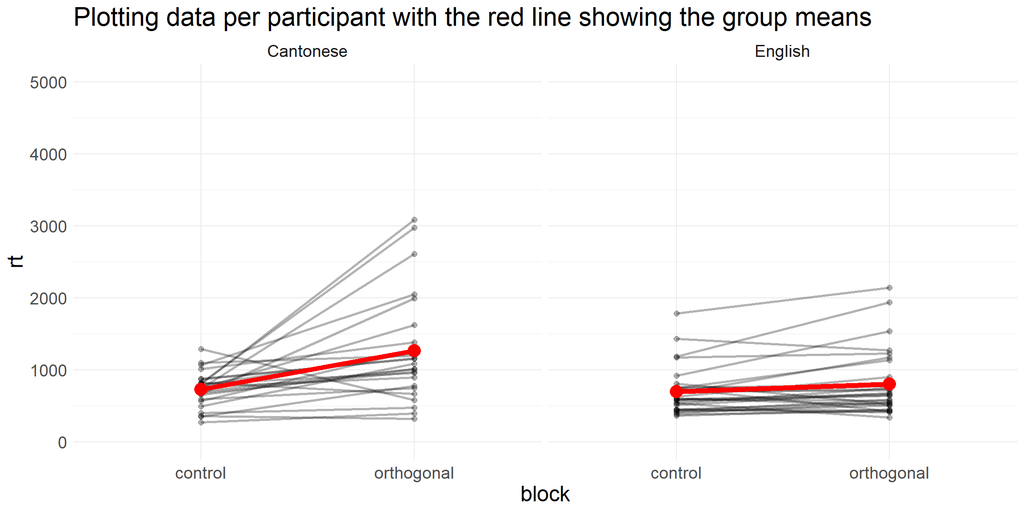

### Linear mixed-effects model (indiviual item: n = 80)

Model ran: lmer(rt ~ block * language_group + (1 + block|participant_id) + (1|item_no) + (1|tone) + (1|syllable)

| effect | group | term | estimate | SE | t | df | p.value |
| --- | --- | --- | --- | --- | --- | --- | --- |
| fixed | NA | (Intercept) | 6.205 | 0.104 | 59.527 | 50.845 | <.001 |
| fixed | NA | blockorthogonal | 0.398 | 0.104 | 3.840 | 32.996 | <.01 |
| fixed | NA | language_groupEnglish | 0.025 | 0.103 | 0.248 | 53.000 | 0.805 |
| fixed | NA | blockorthogonal:language_groupEnglish | -0.347 | 0.100 | -3.478 | 53.004 | <.01 |
| ran_pars | item_no | sd__(Intercept) | 0.152 | NA | NA | NA | NA |
| ran_pars | participant_id | sd__(Intercept) | 0.367 | NA | NA | NA | NA |
| ran_pars | participant_id | cor__(Intercept).blockorthogonal | -0.036 | NA | NA | NA | NA |
| ran_pars | participant_id | sd__blockorthogonal | 0.343 | NA | NA | NA | NA |
| ran_pars | tone | sd__(Intercept) | 0.141 | NA | NA | NA | NA |
| ran_pars | syllable | sd__(Intercept) | 0.126 | NA | NA | NA | NA |

[output cut: 1 more lines]

Comparison reference level: Control block × Cantonese group

- Significant effect of **block**: With the positive estimate, the Cantonese group took longer to response in the orthogonal block than in the control block.
- Significant **block × language_group** interaction: The interaction means the effect of block changes with a change in language group. Here the negative estimate suggests that the effect of Cantonese group showing longer RT in the orthogonal block changes when we look at the performance of the English group. The slope is shallower for the English group.
- The effect of **language_group** did not reach significance level.

### Post-hoc analysis (adjustment method: Bonferroni)

block*language group

```r
emmeans(prop_model_rt, pairwise ~ block | language_group, adjust = "Bonferroni",
              lmer.df = "satterthwaite", lmerTest.limit = 8960)[2]
```

```
## $contrasts
## language_group = Cantonese:
##  contrast             estimate     SE   df t.ratio p.value
##  control - orthogonal  -0.3978 0.1036 33.0  -3.840  0.0005
##
## language_group = English:
##  contrast             estimate     SE   df t.ratio p.value
##  control - orthogonal  -0.0513 0.0991 29.1  -0.517  0.6090
##
## Degrees-of-freedom method: satterthwaite
```

# **Supplementary Analysis of Face-to-face Data**

We analyzed the face-to-face data to supplement the above online results. Since there was not enough face-to-face data from English listeners, we limited the following statistical models to data from the Cantonese listeners. Specifically, we asked whether the face-to-face Cantonese listeners integrally process Thai tones and segmental information.

## Average plots by block and language group

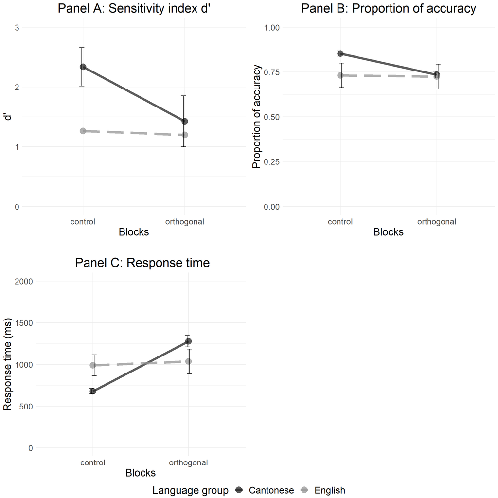

## Accuracy: D’ score

### Average d’ score

| test_group | language_group | block | mean_dprime | sd_dprime | min_dprime | max_dprime |
| --- | --- | --- | --- | --- | --- | --- |
| f2f | Cantonese | control | 2.34 | 0.59 | 1.29 | 3.14 |
| f2f | Cantonese | orthogonal | 1.43 | 0.78 | 0.07 | 2.57 |
| f2f | English | control | 1.26 | NA | 1.26 | 1.26 |
| f2f | English | orthogonal | 1.20 | NA | 1.20 | 1.20 |

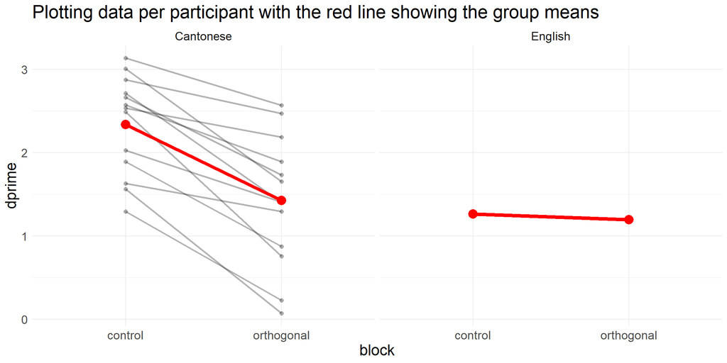

### Pairwise t-test

```
##
##  Paired t-test
##
## data:  f2f_dprime$dprime_control and f2f_dprime$dprime_orthogonal
## t = 7.1082, df = 12, p-value = 0.00001234
## alternative hypothesis: true mean difference is not equal to 0
## 95 percent confidence interval:
##  0.6327737 1.1921567
## sample estimates:
## mean difference
##       0.9124652
```

## Accuracy: Proportion of accuracy

### Average proportion of accuracy

[output not shown]

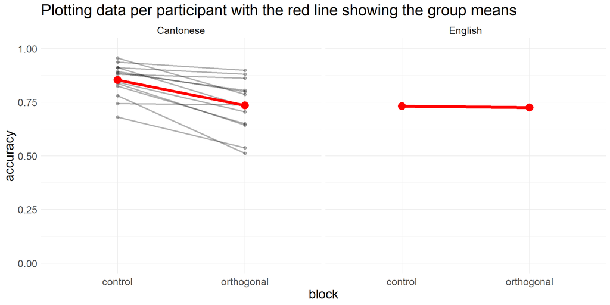

### Logistic mixed-effects model

| effect | group | term | estimate | SE | z | p.value |
| --- | --- | --- | --- | --- | --- | --- |
| fixed | NA | (Intercept) | 2.500 | 0.379 | 6.594 | <.001 |
| fixed | NA | blockorthogonal | -1.031 | 0.257 | -4.015 | <.001 |
| ran_pars | item_no | sd__(Intercept) | 0.683 | NA | NA | NA |
| ran_pars | tone | sd__(Intercept) | 1.198 | NA | NA | NA |
| ran_pars | syllable | sd__(Intercept) | 0.348 | NA | NA | NA |
| ran_pars | participant_id | sd__(Intercept) | 0.747 | NA | NA | NA |
| ran_pars | participant_id | cor__(Intercept).blockorthogonal | -0.296 | NA | NA | NA |
| ran_pars | participant_id | sd__blockorthogonal | 0.433 | NA | NA | NA |

## Response time

### Average response time

[output not shown]

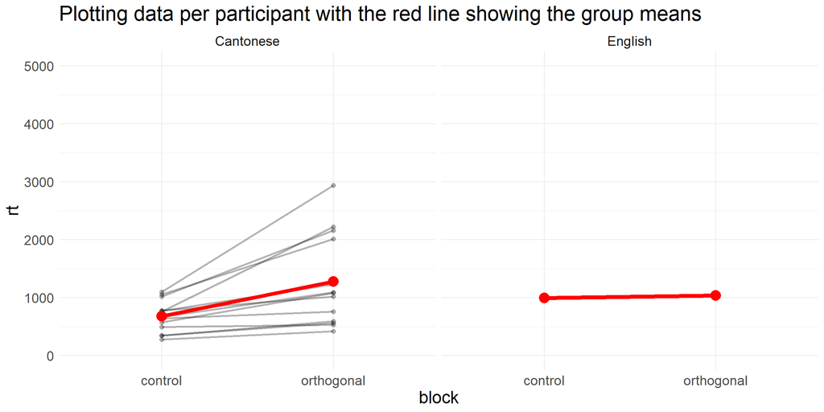

### Linear mixed-effects model

| effect | group | term | estimate | SE | t | df | p.value |
| --- | --- | --- | --- | --- | --- | --- | --- |
| fixed | NA | (Intercept) | 6.118 | 0.133 | 45.998 | 18.434 | <.001 |
| fixed | NA | blockorthogonal | 0.505 | 0.092 | 5.464 | 17.900 | <.001 |
| ran_pars | item_no | sd__(Intercept) | 0.195 | NA | NA | NA | NA |
| ran_pars | tone | sd__(Intercept) | 0.157 | NA | NA | NA | NA |
| ran_pars | syllable | sd__(Intercept) | 0.102 | NA | NA | NA | NA |
| ran_pars | participant_id | sd__(Intercept) | 0.418 | NA | NA | NA | NA |
| ran_pars | participant_id | cor__(Intercept).blockorthogonal | 0.381 | NA | NA | NA | NA |
| ran_pars | participant_id | sd__blockorthogonal | 0.239 | NA | NA | NA | NA |
| ran_pars | Residual | sd__Observation | 0.799 | NA | NA | NA | NA |